# Prediction of Health Insurance Costs with Linear Regression

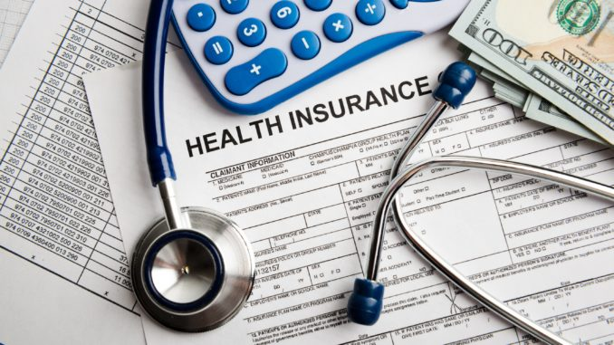

**Motivation:** Health insurance is a type of insurance that covers the whole or a part of the risk of a person incurring medical expenses. Health insurance companies desire to provide appropriate insurance for each person such that it may enhance the resources allocation of the company and may increase the loans they give.

**Goal:** Build a regression model which predicts health expenses for potential insured based on their personal information.

**Data:** Tabular data with 1,338 records. Each record consists of personal information about a potential insured. There are 7 explainable variables: age, sex, bmi, smoker/nonsmoker, region, number of children and family size. The response vector is the health expenses (in dolars) of each potential insured. The data is obtained from the U.S only.

```
##   X age    sex  bmi children smoker    region family_size expenses
## 1 1  19 female 27.9        0    yes southwest           2 16884.92
## 2 2  18   male 33.8        1     no southeast           3  1725.55
## 3 3  28   male 33.0        3     no southeast           5  4449.46
## 4 4  33   male 22.7        0     no northwest           2 21984.47
## 5 5  32   male 28.9        0     no northwest           2  3866.86
## 6 6  31 female 25.7        0     no southeast           2  3756.62
```

### **Explanatory Analysis**

#### **Variables Distribution**

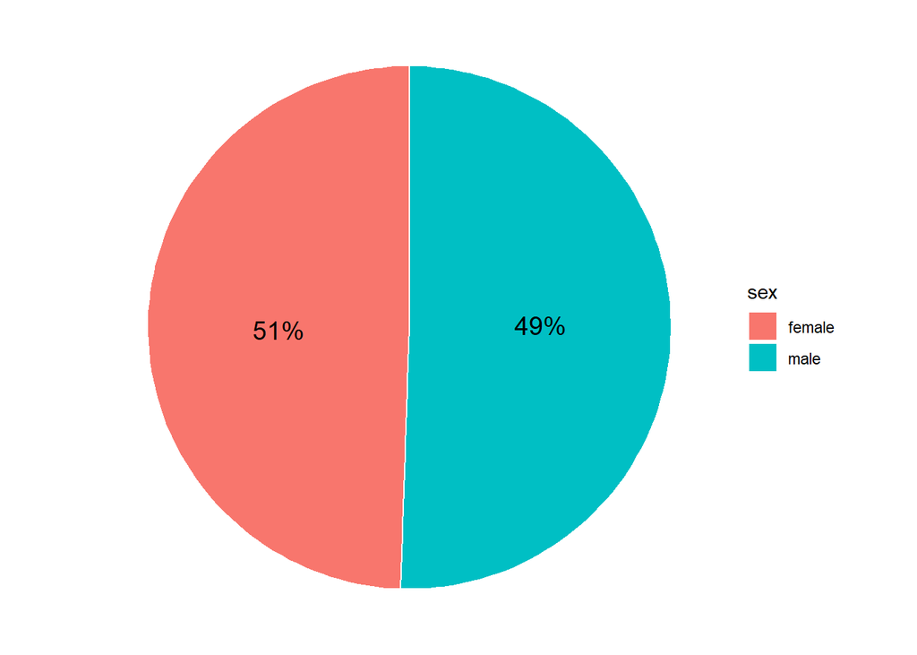

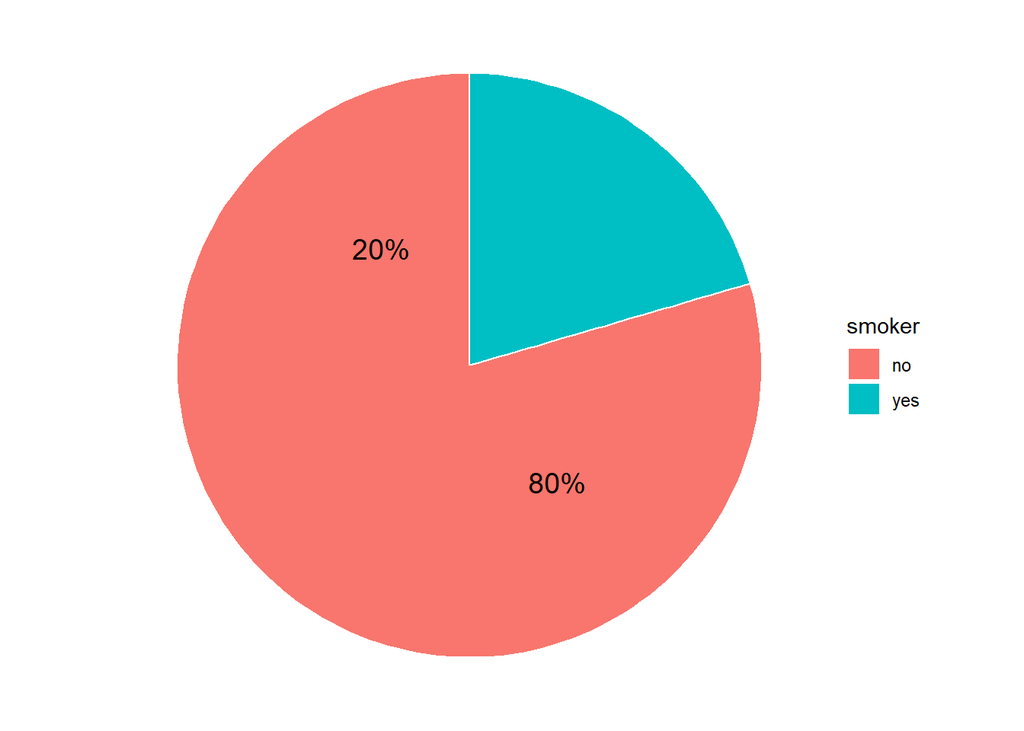

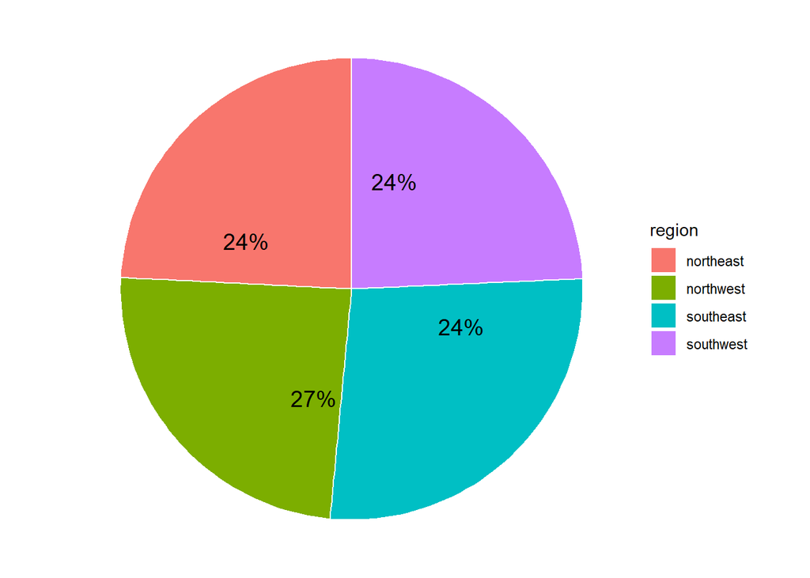

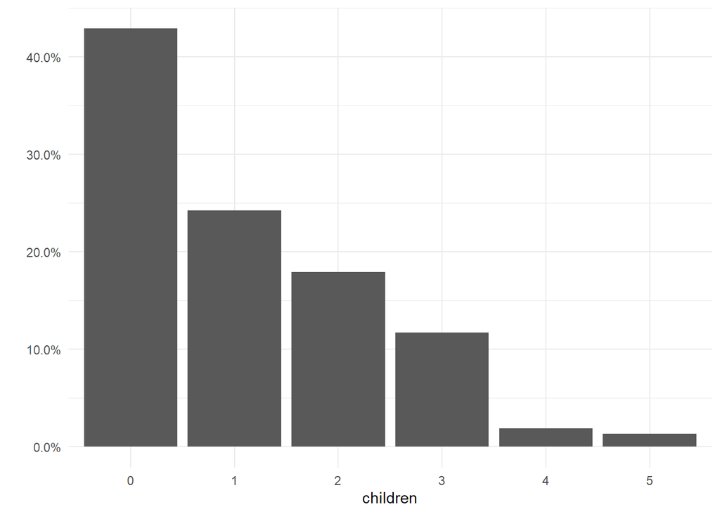

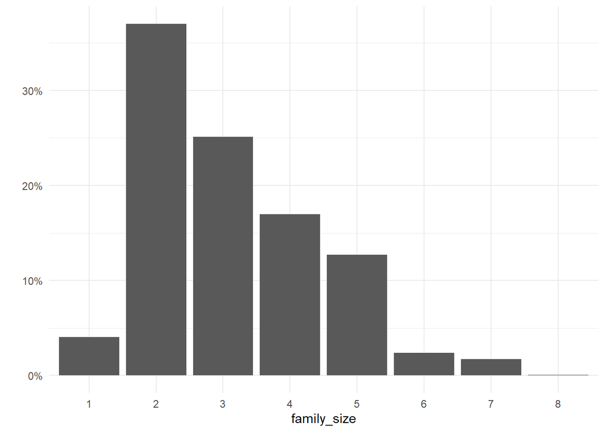

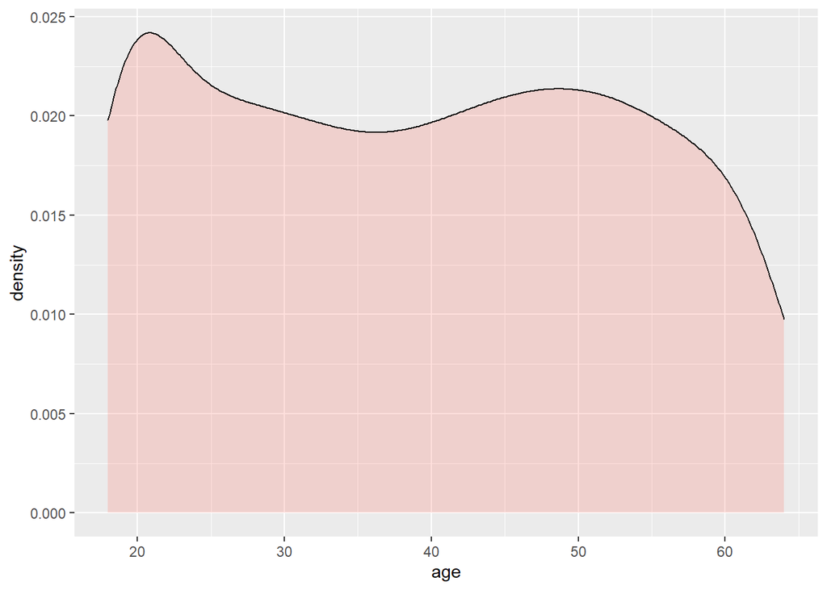

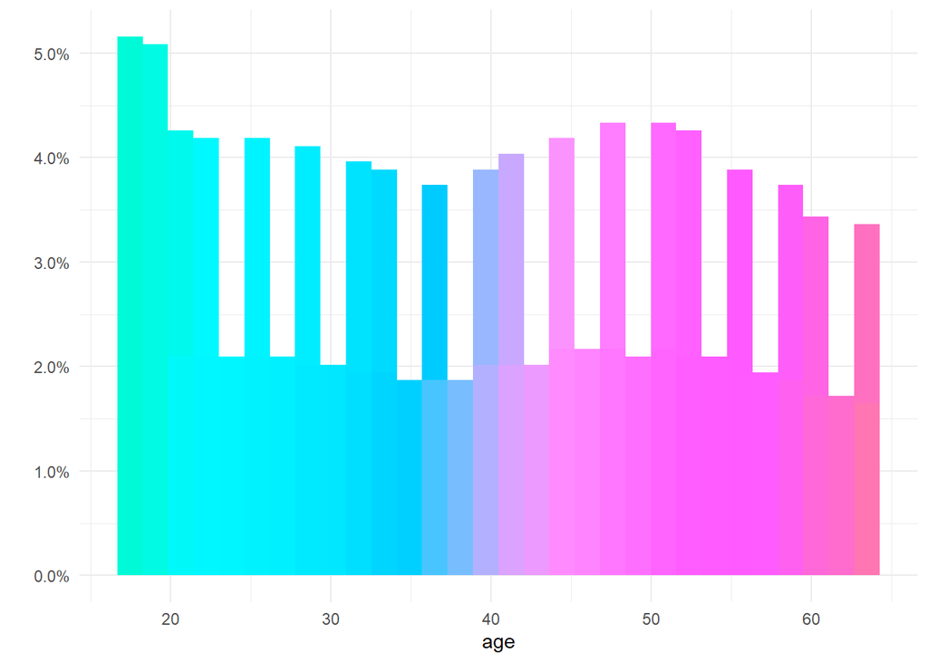

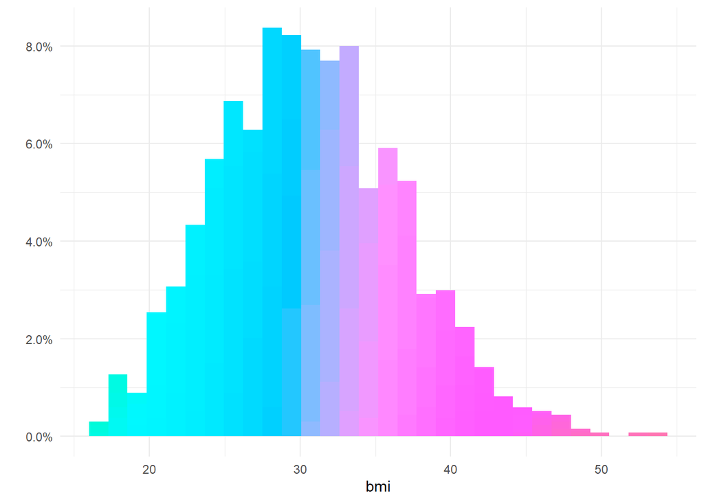

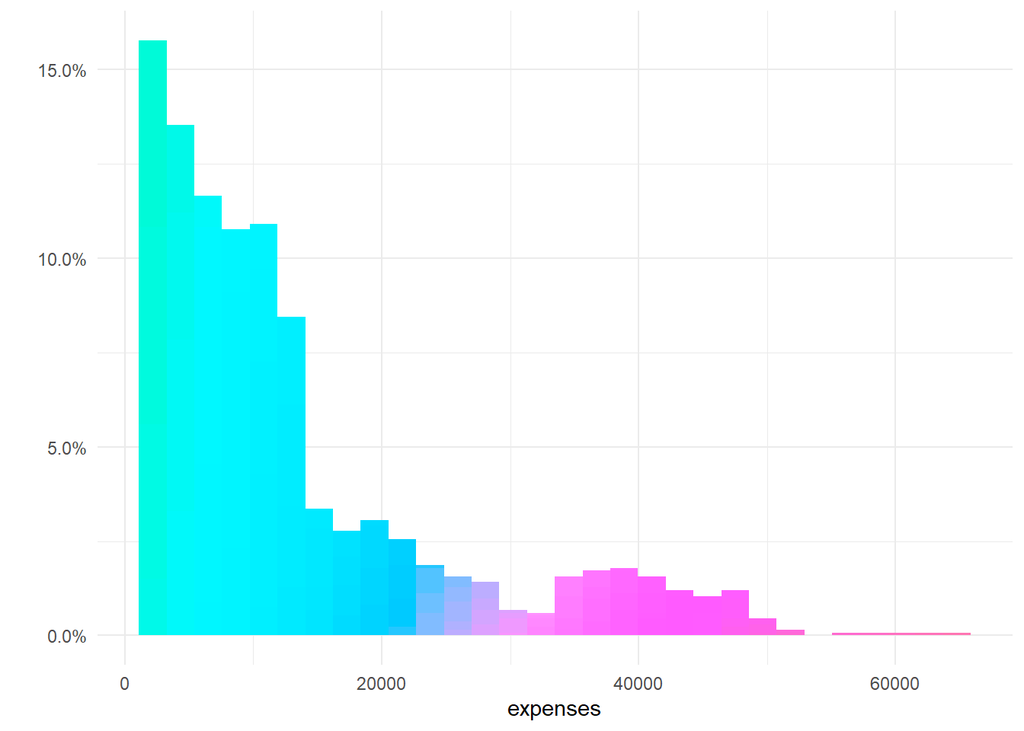

#### **Scatter plots for continues variables and semi-continues variables (age)**

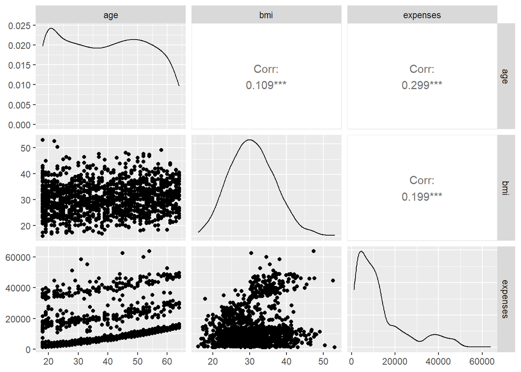

#### **Box plots**

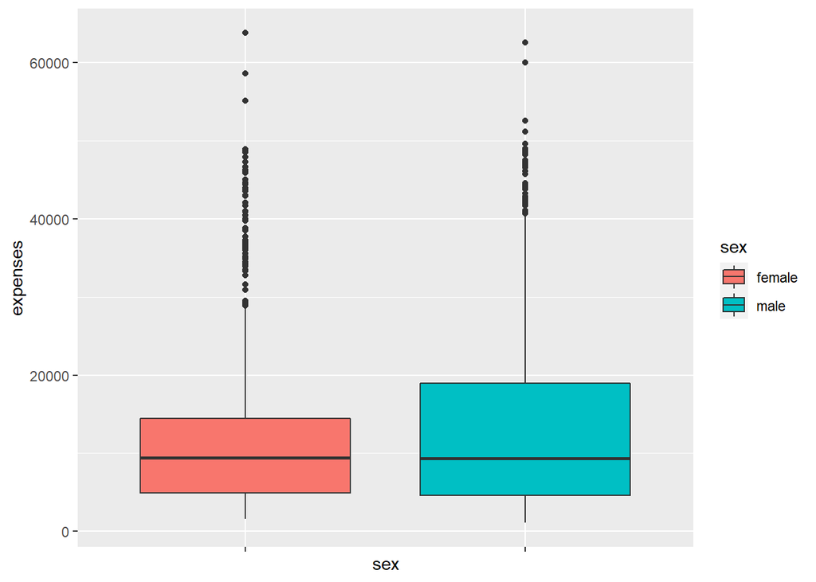

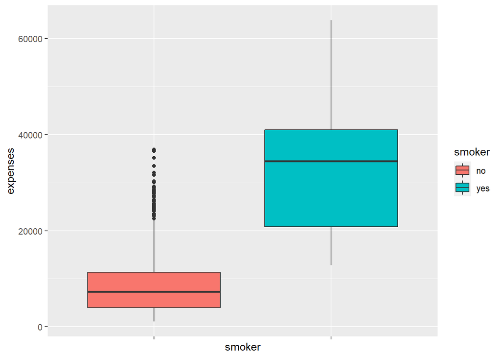

It can be seen that smokers have higer health expensess.

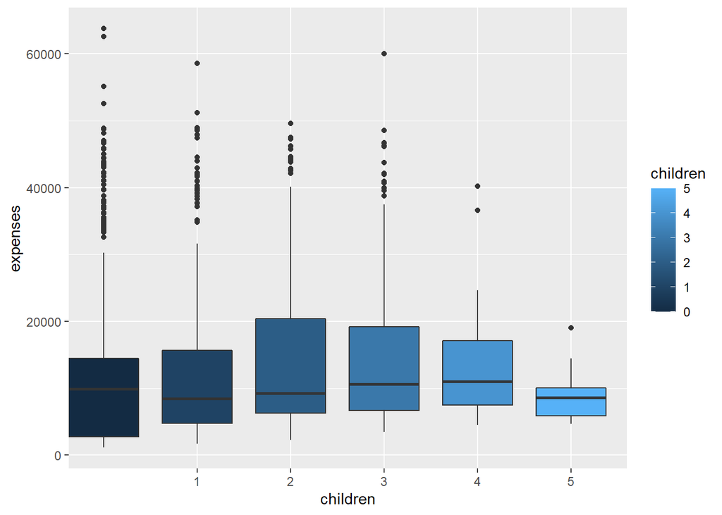

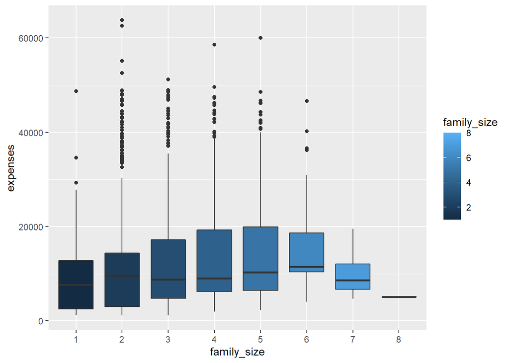

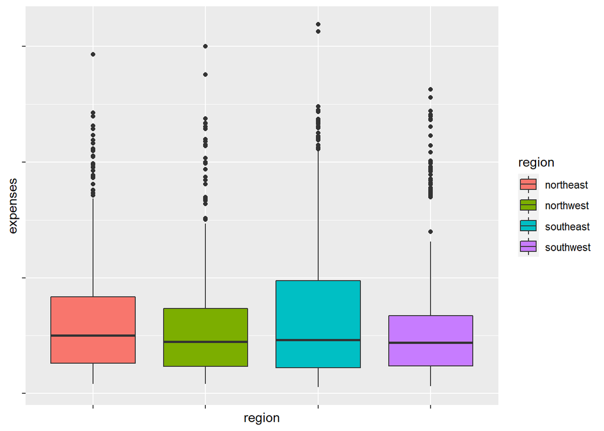

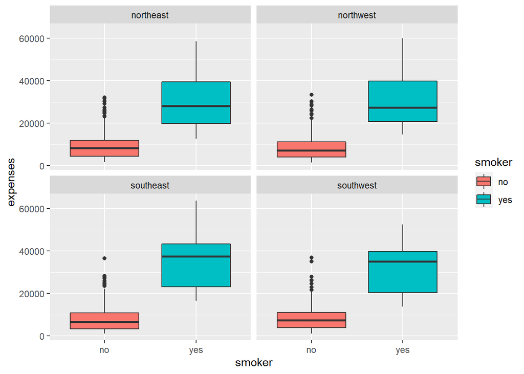

## Scatter Plots

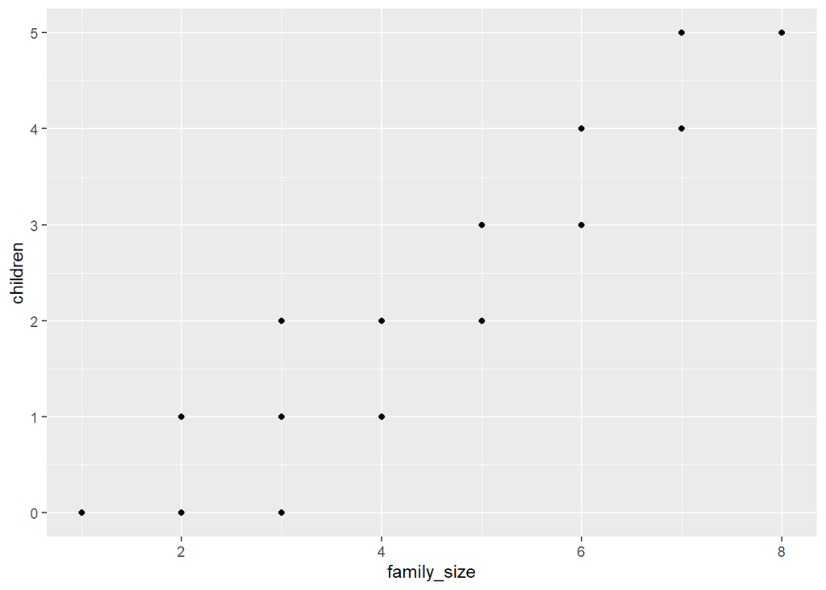

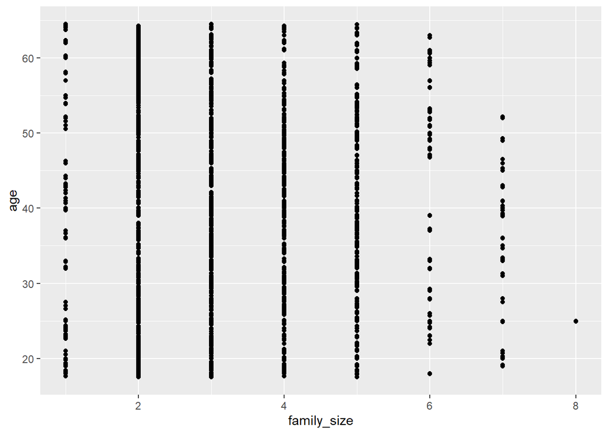

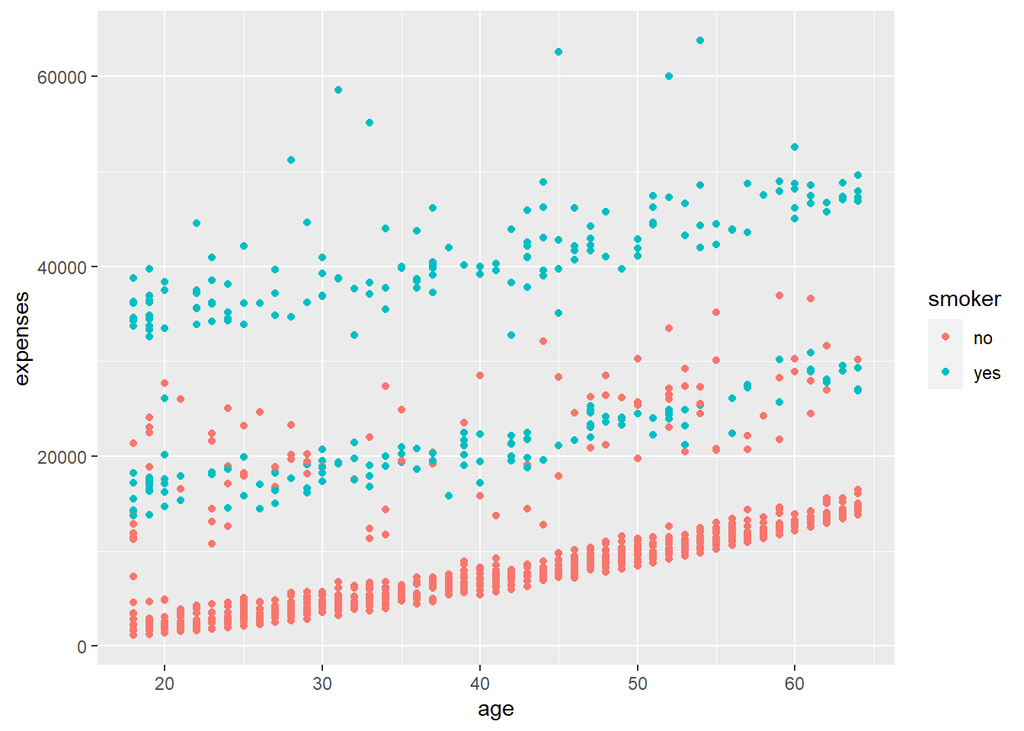

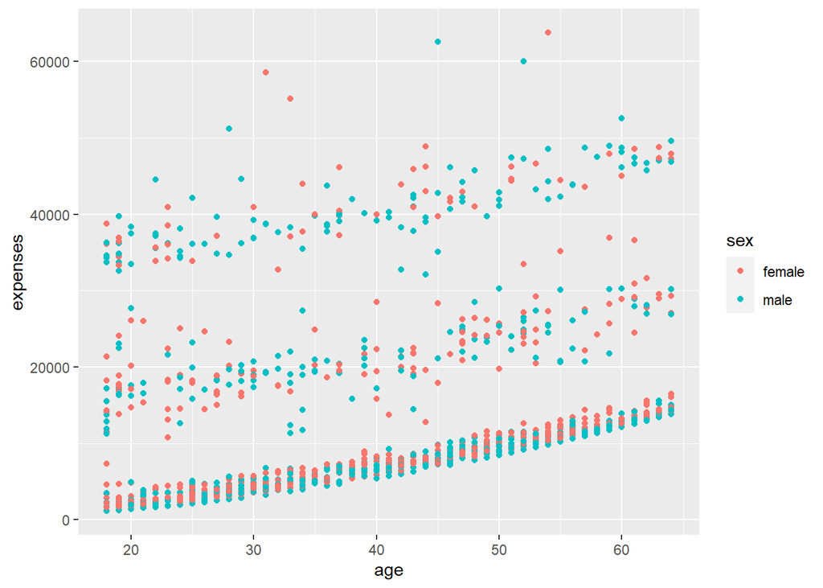

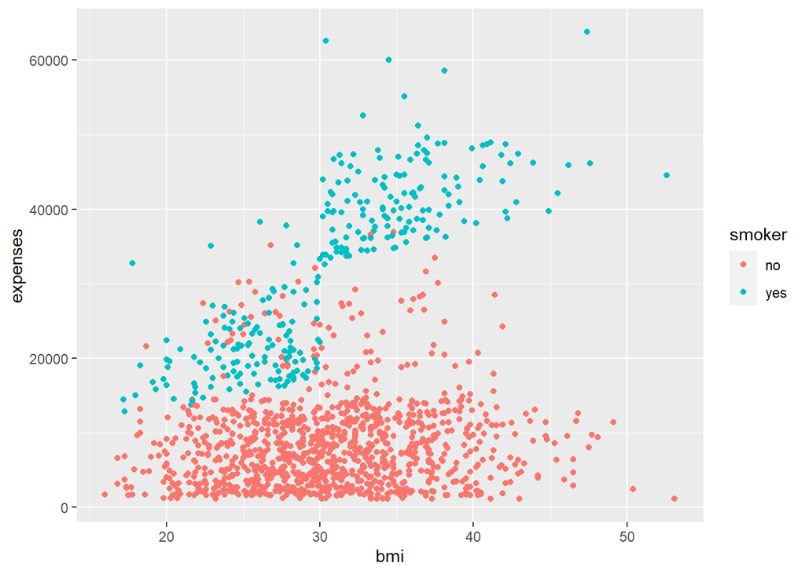

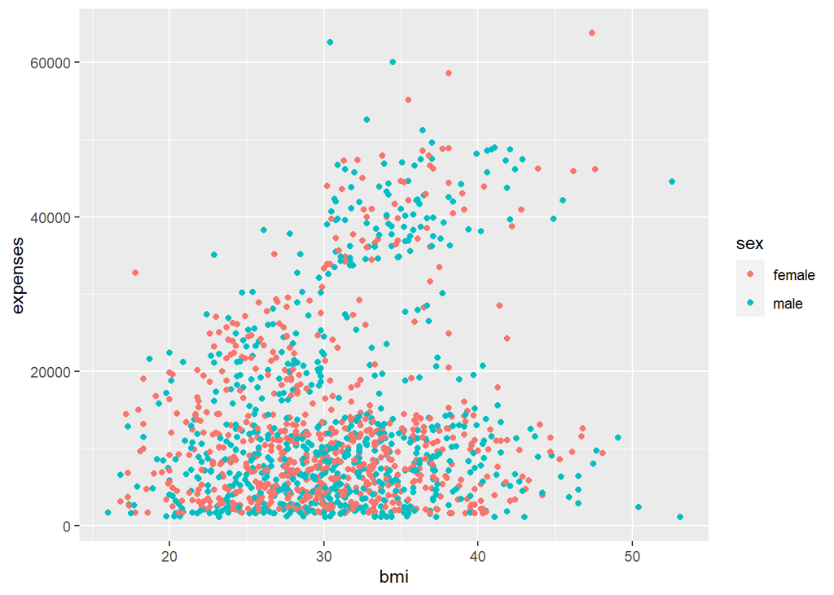

We can see from the figure “age vs expensess” that as the age getting higer also does the expeness. In addition we can see that non-smokers have low expensess compare to smokers, and that are 2-order polynomial patterns for that in the plot. Therefore we may benfit from add an interaction "’smoker*age", as well as add the variable $age^2$ to the model.

## More plots

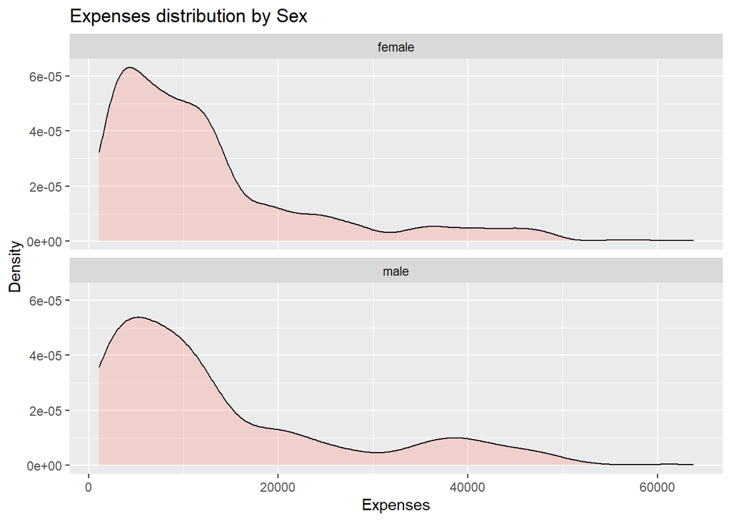

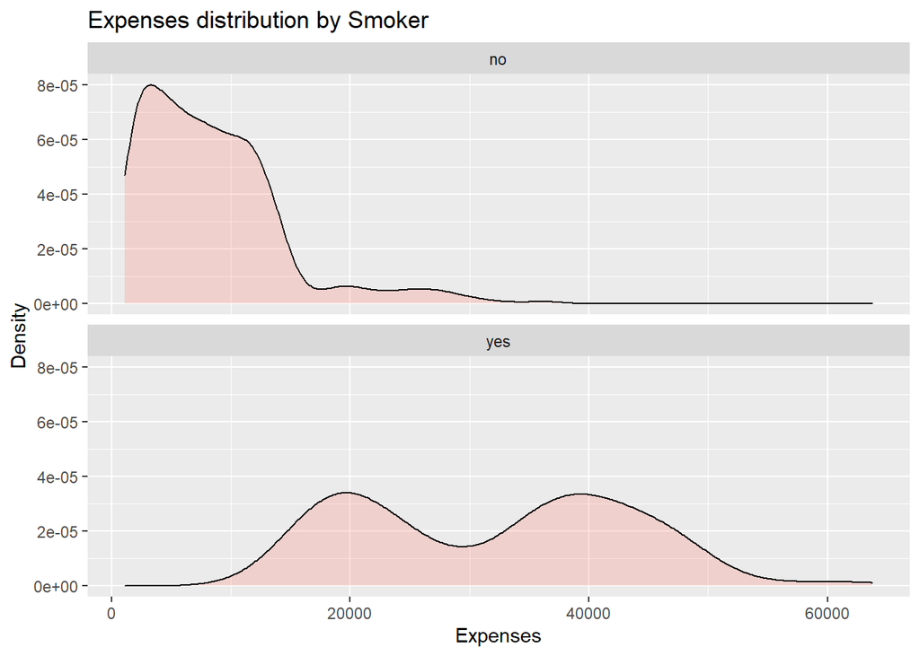

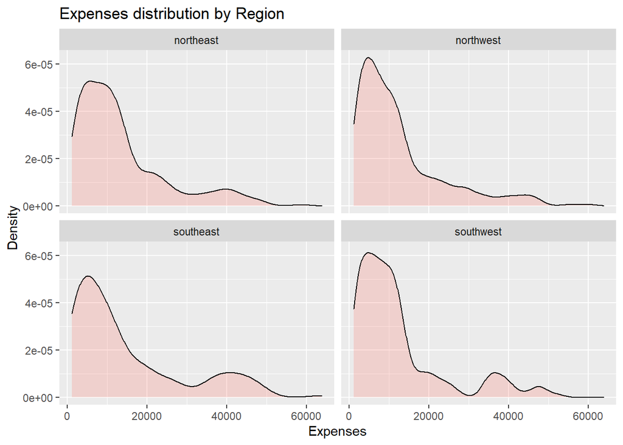

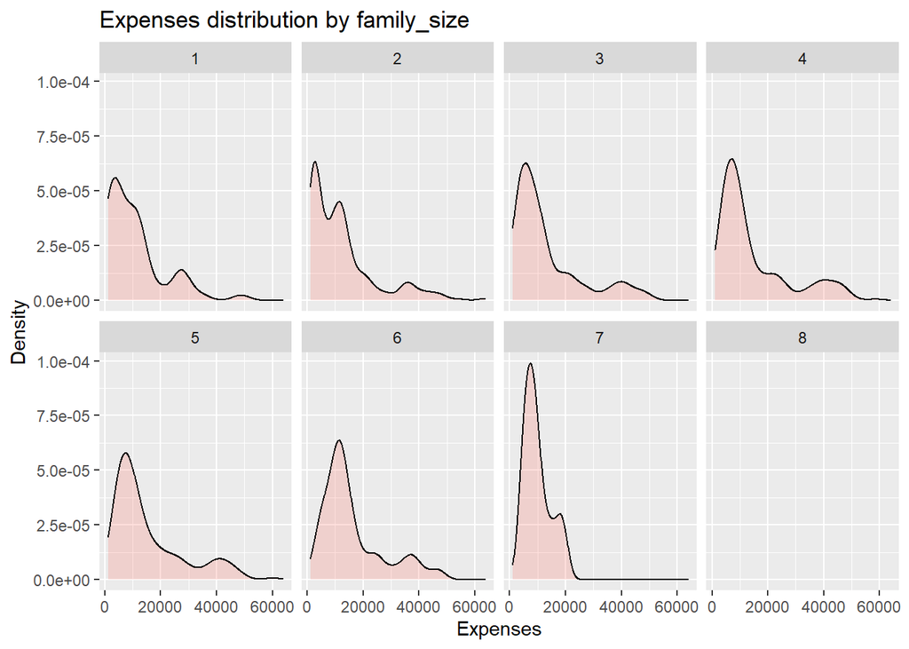

## Check for Multicollinearity

```
## Tolerance and Variance Inflation Factor
## ---------------------------------------
##         Variables Tolerance      VIF
## 1             age 0.9832591 1.017026
## 2         sexmale 0.9910818 1.008998
## 3             bmi 0.9011468 1.109697
## 4        children 0.1074144 9.309743
## 5       smokeryes 0.9871087 1.013060
## 6 regionnorthwest 0.6582757 1.519120
## 7 regionsoutheast 0.6049398 1.653057
## 8 regionsouthwest 0.6538617 1.529375
## 9     family_size 0.1072980 9.319841
##
##
## Eigenvalue and Condition Index
```

[output cut: 34 more lines]

It can be seen that “children” and “family_size” are colinear with each other (as expected). We can see it because they both have high VIF (~9), and becausein the row of condition index with high value (26.26), thier variance proportions are close to 0.9. So we drop “children” and reapt multicollinearity checking without it:

```
## Tolerance and Variance Inflation Factor
## ---------------------------------------
##         Variables Tolerance      VIF
## 1             age 0.9832597 1.017025
## 2         sexmale 0.9910953 1.008985
## 3             bmi 0.9037240 1.106532
## 4       smokeryes 0.9877898 1.012361
## 5 regionnorthwest 0.6582836 1.519102
## 6 regionsoutheast 0.6051822 1.652395
## 7 regionsouthwest 0.6539306 1.529214
## 8     family_size 0.9949292 1.005097
##
##
## Eigenvalue and Condition Index
## ------------------------------
```

[output cut: 30 more lines]

It seems there are no other variables that colinear with each other, so we remain these features.

### **Basic Model**

Now we build a baseline model which consists only from the variables “age” and “smoker”. we chosed these variables because it seems from the plots that both are important.

In order to build the model properly, we e split the data into 75% train set and 25% test set.We will use the train set foe model development, and we will use the test set for evaluate the final model.

```r
basic_model = lm(expenses ~ age + smoker , data = train)
summary(basic_model)
```

```
##
## Call:
## lm(formula = expenses ~ age + smoker, data = train)
##
## Residuals:
##      Min       1Q   Median       3Q      Max
## -15311.6  -2081.0  -1399.8   -300.5  29268.9
##
## Coefficients:
##             Estimate Std. Error t value Pr(>|t|)
## (Intercept) -1826.66     608.54  -3.002  0.00275 **
## age           261.45      14.32  18.261  < 2e-16 ***
## smokeryes   23023.96     497.65  46.265  < 2e-16 ***
## ---
## Signif. codes:  0 '***' 0.001 '**' 0.01 '*' 0.05 '.' 0.1 ' ' 1
##
## Residual standard error: 6401 on 1000 degrees of freedom
## Multiple R-squared:  0.711,  Adjusted R-squared:  0.7104
## F-statistic:  1230 on 2 and 1000 DF,  p-value: < 2.2e-16
```

#### **Residuals Analysis**

Before we look at the statistical measures for Model Quality, we should check the residual plots in order to verify the assumptions of an OLS linear regression model:

1. The residuals have to be normally distributed
2. The error terms need to be independent of each other (need to be random)

If some assumptions are violated in the fitted model, we risk producing results (regression coefficients and other numeric results) that we can’t trust.

Residual plots display the residual values on the y-axis and fitted values, or another variable, on the x-axis, and it can be used to display unwanted patternss that incdicates of assumption violation.

**Check the assumption that the residuals are normaly distributed**

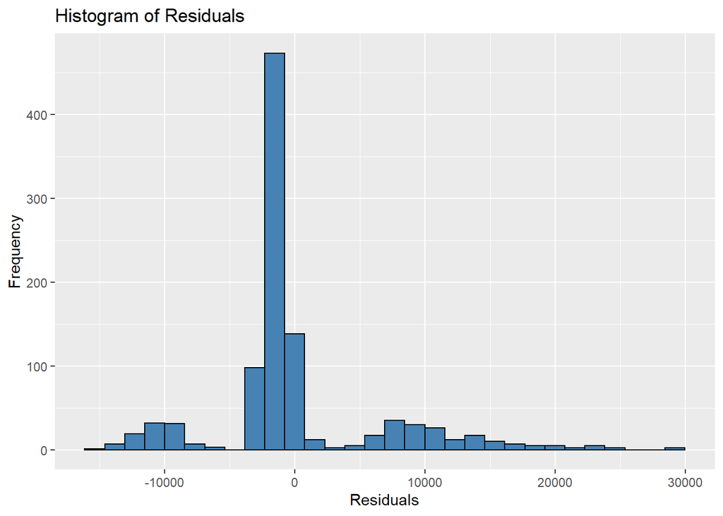

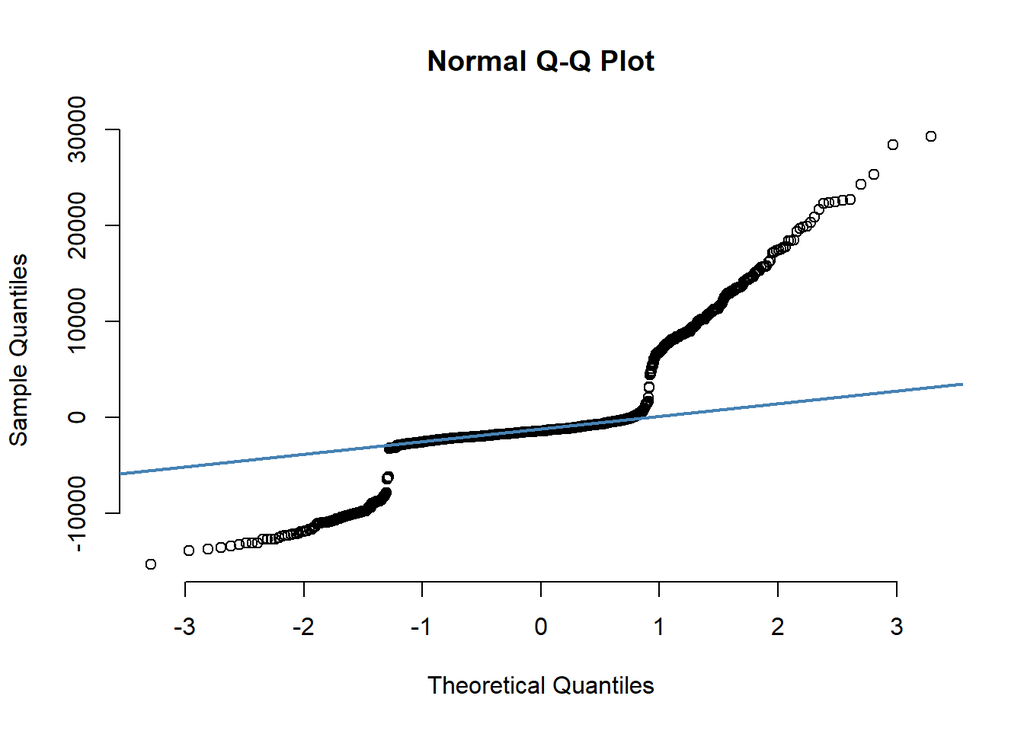

We can see from the residuals histogram and from the QQ-plot that the residuals distributon is right-skewd and has long right tail - meaning the residuals arn’t normally distubuted. We can try to fix this by transforming the resposne / explainable vaiables or by adding features.

**Check the assumption that the residuals are randomly dispersed around the 0 horizontal axis**

The idea is that the gap between the expected and observed values must not be predictable. Or, no explanatory power should be in the error. If it can use the error to make predictions about the response, the model has a problem.